# ECE 131A Final Project Report

**by Sanjit Sarda** Winter 2023

## Table of Contents:

1. Problem 1: Tossing a fair and unfair die
   - Simulating the toss of a fair die
   - Analytical probability of getting an odd number
   - Comparing theoretical and experimental results
   - Repetition of the experiment with an unfair die
2. Problem 2: Maximum Likelihood Estimation
   - Analytically deriving the Maximum Likelihood Equation for a Gaussian distribution
   - Analytically deriving the expressions for $\mu$ and $\sigma^2$ and applying them to the data
   - Comparing the distribution of the data with the theoretical distribution
3. Problem 3: Naive Bayes Classifier
   - Estimating individual class probabilities
   - Estimating conditional probabilities
   - Computing the probability of given events.
   - Predicting purchase probability.
4. Problem 4: Central Limit Theorem
   - Distributions of sum of $n$ $X_i$ = $\mathcal{U}[3, 7]$'s for $n$ = 1, 2, 3, 10, 30, 100
   - Analytical Calculation of the mean and variance of the sum of n Uniform random variables
   - Generating gaussian RV with analytical mean and variance
   - Repetition of the experiment for $X_i$ = Biased die
   - (Bonus) Exact PDFs for the sum of n Uniform random variables
5. Appendix: Code for the problems

### 1. (25 pts) *Tossing a fair and unfair die*.

Suppose you have a 10-sided die, with sides numbered 1, 2, 3, 4, 5, 6, 7, 8, 9, and 10.

#### (a) Write a program (in any programming language) to simulate the tossing of a 10-sided fair die (i.e., all sides are equally likely), for t = 50, 100, 1000, 2000, 3000, 10000, and 100000 tosses. Based on the simulation, what is the estimated probability of obtaining an odd number?

Answer:

Results of simulating values for a fair 10 sided die:

For 50 tosses, the results are: [8, 5, 5, 8, 5, 6, 4, 2, 2, 5] and the estimated probability of getting an odd number is: **0.48**

For 100 tosses, the results are: [13, 6, 5, 9, 17, 9, 11, 8, 15, 7] and the estimated probability of getting an odd number is: **0.61**

For 1000 tosses, the results are: [100, 97, 103, 94, 113, 94, 97, 99, 107, 96] and the estimated probability of getting an odd number is: **0.52**

For 2000 tosses, the results are: [198, 206, 190, 201, 182, 185, 217, 205, 221, 195] and the estimated probability of getting an odd number is: **0.504**

For 3000 tosses, the results are: [314, 308, 300, 348, 290, 285, 287, 301, 285, 282] and the estimated probability of getting an odd number is: **0.492**

For 10000 tosses, the results are: [972, 1021, 992, 1031, 1027, 1037, 966, 994, 984, 976] and the estimated probability of getting an odd number is: **0.4941**

For 100000 tosses, the results are: [10038, 10091, 9945, 10115, 9970, 9963, 10171, 9870, 10030, 9807] and the estimated probability of getting an odd number is: **0.50154**

Additionally, here is a plot depicting the results:

[figure not shown]

#### (b) Suppose X is a random variable denoting the outcome of a die toss. Based on mathematical analysis and probability theory, what is the probability that X has an odd value?

Answer:

The PMF of the RV X is a discrete uniform distribution with 10 equally likely outcomes.

The PMF of X is given by: $ f_X(x) = \begin{cases} \frac{1}{10} & \text{if } 0 \leq x \leq 10 \\ 0 & \text{otherwise} \end{cases} $

The probability of obtaining an odd number is given by: $P(1) + P(3) + P(5) + P(7) + P(9) = \frac{1}{10}*5 = \frac{1}{2}$

Therefore the probability of obtaining an odd number is 0.5.

#### (c) Refer back to part (a). Does it agree with the theoretical result in (b)?

Answer:

Percentage error between the estimated and theoretical probabilities:

For 50 tosses, the error is: **4.0 %**

For 100 tosses, the error is: **22.0 %**

For 1000 tosses, the error is: **4.0 %**

For 2000 tosses, the error is: **0.8 %**

For 3000 tosses, the error is: **1.6 %**

For 10000 tosses, the error is: **1.18 %**

For 100000 tosses, the error is: **0.308 %**

[figure not shown]

Based on the % error calculations above, the theoretical result in (b) agrees with the simulation results in (a). The % errors are 4.0%, 22.0%, 0.8%, 1.6%, 1.18% and 0.308%. Apart from the % Error for n = 100, all the other % errors are less than 5%. In fact, the % error for n = 100000 is less than 0.5%.

Therefore, it is safe to say that the theoretical result in (b) agrees with the simulation results in (a).

#### (d) Repeat parts (a), (b), and (c) with a 10-sided die that has the property that any odd number is twice as likely as an even number and all even numbers are equally likely.

Answer:

Results of simulating values for an unfair 10 sided die:

For 50 tosses, the results are: [6, 3, 3, 6, 8, 0, 8, 6, 5, 5] and the probability of getting an odd number is: 0.6

For 100 tosses, the results are: [15, 8, 11, 6, 15, 10, 8, 6, 15, 6] and the probability of getting an odd number is: 0.64

For 1000 tosses, the results are: [150, 78, 128, 73, 132, 54, 145, 77, 112, 51] and the probability of getting an odd number is: 0.667

For 2000 tosses, the results are: [273, 134, 266, 117, 281, 123, 282, 122, 286, 116] and the probability of getting an odd number is: 0.694

For 3000 tosses, the results are: [404, 202, 395, 197, 383, 193, 396, 233, 395, 202] and the probability of getting an odd number is: 0.658

For 10000 tosses, the results are: [1318, 625, 1338, 682, 1352, 673, 1337, 659, 1340, 676] and the probability of getting an odd number is: 0.668

For 100000 tosses, the results are: [13433, 6680, 13311, 6618, 13408, 6608, 13032, 6832, 13368, 6710] and the probability of getting an odd number is: 0.666

Additionally, here is a plot depicting the results:

[figure not shown]

The probability of obtaining an odd number is given by: $P(1) + P(3) + P(5) + P(7) + P(9) = \frac{2}{15}*5 = \frac{2}{3}$

Therefore the probability of obtaining an odd number is $\frac{2}{3}$.

Percentage error between the estimated and theoretical probabilities:

For 50 tosses, the error is: 10.0%

For 100 tosses, the error is: 4.0%

For 1000 tosses, the error is: 0.05%

For 2000 tosses, the error is: 4.1%

For 3000 tosses, the error is: 1.35%

For 10000 tosses, the error is: 0.275%

For 100000 tosses, the error is: 0.172%

[figure not shown]

Answer:

Based on the % error calculations above, the theoretical result agrees with the simulation results. The % errors are 10.0%, 4.0%, 0.05%, 4.1%, 1.35%. 0.275%, 0.172%. Apart from the % Error for n = 50, all the other % errors are less than 5%. In fact, the % error for n = 100000 is less than 0.2%.

### 2. (25 pts) *Maximum Likelihood Estimation*.

Consider the data sequence ${x_1, x_2, . . . , x_n}$, of length n = 100000 provided in the file “data.txt”. It is known that the data is normally distributed. However, the mean $\mu$ and the variance $\sigma^2$ of this normal distribution is unknown. In this problem, you are required to estimate µ and σ using methods learned in the course. Assume that the data points are i.i.d. random variables $X_1, X_2, X_3 ... X_n$ where each $X_i$ ~ $\mathcal{N}(\mu, \sigma^2)$. The data set ${x_1, x_2, . . . , x_n}$ provided in the file “data.txt” are the observed values of these random variables. You will determine $\mu$ and $\sigma$ for the data so that the data matches to its most likely Gaussian bell curve. Mathematically, you determine $\mu$ and $\sigma$ that maximize the probability of observing the data given the choice of $\mu$ and $\sigma$. Let $f_{X_1}, f_{X_2}, . . . , f_{X_n}(x_1,x_2,x_3...x_n|\mu,\sigma)$ be the joint density of the RVs $X_1, X_2, X_3 ... X_n$ evaluated at our data points ${x_1, x_2, . . . , x_n}$ given our choice of $\mu$ and $\sigma$. The maximum likelihood estimates $\mu_{MLE}$ and $\sigma_{MLE}$ for $\mu$ and $\sigma$ are found as follows:

$$\mu_{MLE} = argmax_{\mu} log(f_{X_1}, f_{X_2}, . . . , f_{X_n}(x_1,x_2,x_3...x_n|\mu,\sigma))$$$$\sigma_{MLE} = argmax_{\sigma} log(f_{X_1}, f_{X_2}, . . . , f_{X_n}(x_1,x_2,x_3...x_n|\mu_{MLE},\sigma))$$

#### (a) Analytically show that:

$$log(f_{x_1,x_2...x_n}(x_1,x_2...x_n|\mu,\sigma)) = -\frac{n}{2}log(2\pi\sigma^2)-\sum\limits_{i=1}^n\frac{(x_i-\mu)^2}{2\sigma^2}$$

Answer: $$\log(f_{X_1,X_2,...,X_n}(x_1,x_2,...,x_n|\mu,\sigma))$$ $$= \log\left(\prod\limits_{i=1}^n \frac{1}{\sqrt{2\pi\sigma^2}}e^{-\frac{(x_i-\mu)^2}{2\sigma^2}}\right)$$ $$= \sum\limits_{i=1}^n \log\left(\frac{1}{\sqrt{2\pi\sigma^2}}e^{-\frac{(x_i-\mu)^2}{2\sigma^2}}\right)$$ $$= \sum\limits_{i=1}^n \left[\log\left(\frac{1}{\sqrt{2\pi\sigma^2}}\right)-\frac{(x_i-\mu)^2}{2\sigma^2}\right]$$ $$= \sum\limits_{i=1}^n \left[-\frac{1}{2}\log(2\pi\sigma^2)-\frac{(x_i-\mu)^2}{2\sigma^2}\right]$$ $$= -\frac{n}{2}\log(2\pi\sigma^2)-\sum\limits_{i=1}^n\frac{(x_i-\mu)^2}{2\sigma^2}$$

Therefore we have proved that $$log(f_{x_1,x_2...x_n}(x_1,x_2...x_n|\mu,\sigma)) = -\frac{n}{2}log(2\pi\sigma^2)-\sum\limits_{i=1}^n\frac{(x_i-\mu)^2}{2\sigma^2}$$

#### (b) Find analytical expressions for $\mu_{MLE}$ and $\sigma_{MLE}$ in terms of the data $x_1, x_2, ..., x_n$ by using the equation derived in (a) in the equations for $\mu_{MLE}$ and $\sigma_{MLE}$. For the data provided in `’data.txt’`, find the values of $\mu_{MLE}$ and $\sigma_{MLE}$ using the analytical expressions derived.

Answer:

To find $\mu_{MLE}$ we start with: $$\mu_{MLE} = argmax_{\mu} log(f_{X_1}, f_{X_2}, . . . , f_{X_n}(x_1,x_2,x_3...x_n|\mu,\sigma))$$ To maximize with respect to $\mu$, we take the derivative of the log-likelihood function with respect to $\mu$ and set it equal to 0. $$\frac{d}{d\mu}log(f_{X_1}, f_{X_2}, . . . , f_{X_n}(x_1,x_2,x_3...x_n|\mu,\sigma))=0$$ $$=\frac{d}{d\mu}\left(-\frac{n}{2}\log(2\pi) - n\log(\sigma) - \frac{1}{2\sigma^2}\sum_{i=1}^{n} (x_i - \mu)^2\right)=0$$ $$=\frac{d}{d\mu}\left(- \frac{1}{2\sigma^2}\sum_{i=1}^{n} (x_i - \mu)^2\right)=0$$ $$=-\frac{1}{2\sigma^2}\frac{d}{d\mu}\sum_{i=1}^{n} (x_i - \mu)^2=0$$ $$=-\frac{1}{2\sigma^2}\sum_{i=1}^{n} 2(x_i - \mu)=0$$ $$=\frac{1}{\sigma^2}\sum_{i=1}^{n} (x_i - \mu)=0$$ $$\sum_{i=1}^{n} (x_i) - n\mu=0$$ $$\mu_{MLE}=\frac{1}{n}\sum_{i=1}^{n} x_i$$

Similarly, to find $\sigma_{MLE}$ we start with: $$\sigma_{MLE} = argmax_{\sigma} log(f_{X_1}, f_{X_2}, . . . , f_{X_n}(x_1,x_2,x_3...x_n|\mu_{MLE},\sigma))$$ To maximize with respect to $\sigma$, we take the derivative of the log-likelihood function with respect to $\sigma$ and set it equal to 0. $$\frac{d}{d\sigma}log(f_{X_1}, f_{X_2}, . . . , f_{X_n}(x_1,x_2,x_3...x_n|\mu_{MLE},\sigma))=0$$ $$=\frac{d}{d\sigma}\left(-\frac{n}{2}\log(2\pi) - n\log(\sigma) - \frac{1}{2\sigma^2}\sum_{i=1}^{n} (x_i - \mu_{MLE})^2\right)=0$$ $$=\frac{d}{d\sigma}\left(-n\log(\sigma)-\frac{1}{2\sigma^2}\sum\limits_{i=1}^n(x_i-\mu_{MLE})\right)=0$$ $$=-n\frac{d}{d\sigma}\log(\sigma)-\frac{d}{d\sigma}\frac{1}{2\sigma^2}\sum\limits_{i=1}^n(x_i-\mu_{MLE})^2=0$$ $$=-n\frac{1}{\sigma}+\frac{1}{\sigma^3}\sum\limits_{i=1}^n(x_i-\mu_{MLE})^2=0$$ $$\frac{n}{\sigma}= \frac{1}{\sigma^3}\sum\limits_{i=1}^n(x_i-\mu_{MLE})^2$$ $$\sigma^2=\frac{1}{n}\sum\limits_{i=1}^n(x_i-\mu_{MLE})^2$$ $$\sigma_{MLE}=\sqrt{\frac{1}{n}\sum\limits_{i=1}^n(x_i-\mu_{MLE})^2}$$

Using Maximum Likelihood Estimation, we obtained:

$\mu_{MLE}$ = 20.0

$\sigma_{MLE}$ = 10.0

(c) Plot the PDF of $X_i$ by plotting the histogram of the data ${x_1, x_2, ..., x_n}$ in `’data.txt’`. For the $\mu_{MLE}$ and $\sigma_{MLE}$ obtained in (b), superimpose the histogram with the PDF of a Gaussian random variable with mean $\mu_{MLE}$ and variance $\sigma_{MLE}^2$.

[figure not shown]

### 3. (25 pts) *Naive Bayes Classifier*.

To maximize profit, advertisement companies like Google, Facebook, and Amazon want to target their advertisement to each user. Specifically, given a user and a product to sell, they want to determine whether this user will buy it. In this problem, we will build a classifier to help us determine whether a user will buy a certain product by using historical data.

Some demographic data is collected for 887 users and are provided in user data.csv. This dataset has four fields: i) Whether this user bought the product (1 for did buy and 0 for did not buy), ii) Type of Spender (1 for larger spender, 2 for medium spender, 3 for small spender) iii) Sex of user (1 for Male and 0 for Female), iv) Age of user. We use random variables B, T, S, and A for bought status, type of spender, sex, and age, respectively. In this problem, we are going to build a popular Naive Bayes Classifier to predict B given T, S, and A.

(a) Estimate the individual PMFs for B, T, S, and A by finding the fraction of each realization of these random variables among all data. Plot these PMFs (i.e. 4 PMFs in total).

The PMF of B is: $P(B) = \begin{cases}\frac{545}{887}\text{ if } B = 0\\\frac{342}{887}\text{ if } B = 1\\\end{cases}$

The PMF of T is: $P(T) = \begin{cases}\frac{228}{887}\text{ if } T = 1\\\frac{184}{887}\text{ if } T = 2\\\frac{475}{887}\text{ if } T = 3\\\end{cases}$

The PMF of S is: $P(S) = \begin{cases}\frac{573}{887}\text{ if } S = 0\\\frac{314}{887}\text{ if } S = 1\\\end{cases}$

We will skip writing out the PMF of A because has too many unique values.

[figure not shown]

#### (b) We are interested in how T, S, and A affect B, in the context of the Naive Bayes Classifier; the first step is to estimate the conditional PMF conditioning on the outcome of interest, i.e., survival or not. Estimate and plot the conditional PMFs for T, S, and A separately conditioned on B = 1 and B = 0 (i.e. 6 PMFs in total).

The PMF of T|B=0 is: $P(T|B=0) = \begin{cases}\frac{92}{545}\text{ if } T = 1\\\frac{105}{545}\text{ if } T = 2\\\frac{348}{545}\text{ if } T = 3\\\end{cases}$

The PMF of T|B=1 is: $P(T|B=1) = \begin{cases}\frac{136}{342}\text{ if } T = 1\\\frac{79}{342}\text{ if } T = 2\\\frac{127}{342}\text{ if } T = 3\\\end{cases}$

The PMF of S|B=0 is: $P(S|B=0) = \begin{cases}\frac{462}{545}\text{ if } S = 0\\\frac{83}{545}\text{ if } S = 1\\\end{cases}$

The PMF of S|B=1 is: $P(S|B=1) = \begin{cases}111\text{ if } S = 0\\231\text{ if } S = 1\\\end{cases}$

Once again, we will skip writing out the PMF of A|B=0 and A|B=1 because has too many unique values.

[figure not shown]

#### (c) In the Naive Bayes Classifier, we use the conditional independence assumption. For example, if T, S, and A are conditionally independent on B, then P(T, S, A|B = 0) = P(T|B = 0)P(S|B = 0)P(A|B = 0) and P(T, S, A|B = 1) = P(T|B = 1)P(S|B = 1)P(A|B = 1). Using this assumption, compute P(B = 0, T = 1, S = 0, A ≤ 55) and P(B = 1, T = 1, S = 0, A ≤ 55) based on your estimations in (a) and (b).

Answer:

P(B = 0, T = 1, S = 0, A <= 55) = 0.06969424622052946

P(B = 1, T = 1, S = 0, A <= 55) = 0.04016013252538375

#### (d) Assuming the conditional independence assumption and using your result in (c), compute P(B = 0|T = 1, S = 0, A ≤ 55) and P(B = 1|T = 1, S = 0, A ≤ 55). Predict whether a female whose age is below 55 and who is a large spender will buy this product or not.

Answer:

P(B = 0|T = 1, S = 0, A <= 55) = 0.6344239257110379

P(B = 1|T = 1, S = 0, A <= 55) = 0.3655760742889621

We predict that a female who is under 55 years old and a large spender will not buy this product with probability: 0.6344239257110379

### 4. (25 pts) *Central Limit Theorem*.

Let $X_1, X_2, ..., X_n$ be a sequence of i.i.d. random variables with finite mean $\mu$ and finite variance $\sigma^2$. Let $Z_n$ be the mean of the first $n$ random variables in the sequence: $$Z_n = \frac{1}{n}\sum_{i=1}^{n} X_i$$ In this problem, we will plot the PDF of $Z_n$ by generating t = 10^4 samples of $Z_n$ and plotting the histogram of the generated samples.

#### (a) Let $X_i$ for i = 1, 2, ... be a uniform continuous random variable taking values in the interval (3, 7). Write a program to plot the PDF of Z_n. Consider n = 1, 2, 3, 10, 30, 100 and compare your results across different $n$'s.

Answer:

[figure not shown]

#### (b) Calculate analytically the mean and the variance of $X_i$ and of $Z_n$ in part (a).

Answer:

$X_i$ is U[3,7] so $E[X_i]=\frac{3+7}{2}=5$ and $Var[X_i]=\frac{(b-a)^2}{12}=\frac{4}{3}$

$Z_n$ is $\frac{1}{n}\sum_{i=1}^{n} X_i$ so $E[Z_n]=n\frac{1}{n}E[X_i]=5$ and $Var[Z_n]=n\frac{1}{n^2}\sum_{i=1}^{n} Var[X_i]=\frac{4}{3n}$

Expectations and Variances:

For $n=1$, $E[Z_1]=5$ and $Var[Z_1]=\frac{4}{3}$

For $n=2$, $E[Z_2]=5$ and $Var[Z_2]=\frac{4}{3}\frac{2}{2^2}=\frac{4}{6}$

For $n=3$, $E[Z_3]=5$ and $Var[Z_3]=\frac{4}{3}\frac{3}{3^2}=\frac{4}{9}$

For $n=10$, $E[Z_{10}]=5$ and $Var[Z_{10}]=\frac{4}{3}\frac{10}{10^2}=\frac{4}{30}$

For $n=30$, $E[Z_{30}]=5$ and $Var[Z_{30}]=\frac{4}{3}\frac{30}{30^2}=\frac{4}{90}$

For $n=100$, $E[Z_{100}]=5$ and $Var[Z_{100}]=\frac{4}{3}\frac{100}{100^2}=\frac{4}{300}$

#### (c) Write a program to generate a Gaussian random variable with the same mean and variance as $Z_n$. Superimpose its pdf on the plots from part (a).

Answer:

[figure not shown]

#### (d) Repeat parts (a), (b), and (c) with Xi representing a toss of a 10-sided die that is described in Problem 1(d). Note that Xi and Zn are discrete in this case. Hence, we approximate the PDF of Zn by generating samples of Zn and plotting its histogram.

Remark: In the case when $X_i$’s are discrete (which leads to discrete Zn), the upper faces of the rectangles forming the histogram of Zn converges toward a Gaussian PDF as n approaches infinity and hence even in this case, you should be able to observe the Central Limit Theorem.

Plots:

[figure not shown]

Answer:

Lets first analytically calculate the mean and variance of $X_i$ and $Z_n$: $X_i$ is a 10 sided die where odd numbers are twice as likely as even numbers.

$\therefore E[X_i]=\frac{2}{15}(1+3+5+7+9)+\frac{1}{15}(2+4+6+8+10)= \frac{16}{3}$

$\therefore Var[X_i]=\frac{2}{15}(1^2+3^2+5^2+7^2+9^2)+\frac{1}{15}(2^2+4^2+6^2+8^2+10^2)-\frac{16}{3}^2=\frac{74}{9}$

$Z_n$ is $\frac{1}{n}\sum_{i=1}^{n} X_i$ so $E[Z_n]=n\frac{1}{n}E[X_i]=\frac{16}{3}$ and $Var[Z_n]=n\frac{1}{n^2}\sum_{i=1}^{n} Var[X_i]=\frac{74}{9n}$

For $n=1$, $E[Z_1]=\frac{16}{3}$ and $Var[Z_1]=\frac{74}{9}$

For $n=2$, $E[Z_2]=\frac{16}{3}$ and $Var[Z_2]=\frac{74}{9}\frac{2}{2^2}=\frac{37}{9}$

For $n=3$, $E[Z_3]=\frac{16}{3}$ and $Var[Z_3]=\frac{74}{9}\frac{3}{3^2}=\frac{74}{27}$

For $n=10$, $E[Z_{10}]=\frac{16}{3}$ and $Var[Z_{10}]=\frac{74}{9}\frac{10}{10^2}=\frac{37}{45}$

For $n=30$, $E[Z_{30}]=\frac{16}{3}$ and $Var[Z_{30}]=\frac{74}{9}\frac{30}{30^2}=\frac{37}{135}$

For $n=100$, $E[Z_{100}]=\frac{16}{3}$ and $Var[Z_{100}]=\frac{74}{9}\frac{100}{100^2}=\frac{37}{450}$

Superimposed Gaussian PDFs:

[figure not shown]

#### (e) (*Bonus 10 points*)

Repeat parts (a) and (c) with the same $X_i$ described in part (a), but this time compute and plot the exact PDF of $Z_n$ instead of generating samples. Provide full description of how you computed the exact PDF of $Z_n$.

Exact PDFs:

[figure not shown]

Exact PDF and superimposed Gaussian PDFs:

[figure not shown]

We know that $Z_i$ =$ \frac{1}{n}\sum_{i=1}^{n} X_i$ so $Z_i$ is a sum of $n$ i.i.d. random variables. We also know that the sum of i.i.d. random variables is a convolution of the individual pdfs. So $Z_2$ = $X_i \ast X_{i+1}$ and $Z_3$ = $Z_2 \ast X_{i+2}$ and so on.

So to calculate the PDF of $Z_n$ we need to convolve the PDF of $X_i$ with itself $n$ times.

So we can set $Z_n$ = $X_i$, and then convolve $Z_n$ with $X_i$ $n-1$ times.

When we do this programmatically, we need to sample a bunch of times before convolving since we cant convolve continuous functions. We then need to account for the change in x and y axis when we convolve. To fix the X axis, we need to adjust the linspace of z to be the same as the linspace of the pdf after the convolutions. To fix the Y axis we need to divide the PDf by the integral so that the new PDF integrates to 1.

### Appendix

```python
# Imports
import numpy as np
import matplotlib.pyplot as plt
from IPython.display import display, Latex, Markdown
import pandas as pd
import tqdm
```

```python
# Other setup
# Lets first define a function to generate a gaussian
def gaussian(x, mu, sigma):
    return 1/(sigma*np.sqrt(2*np.pi))*np.exp(-((x-mu)**2)/(2*sigma**2))
# We will also set the random seed for reproducibility
def seed(): # We have to call this function at the beginning of each cell because of the way Jupyter works
    np.random.seed(190804)
```

### 1. (25 pts) *Tossing a fair and unfair die*.

Suppose you have a 10-sided die, with sides numbered 1, 2, 3, 4, 5, 6, 7, 8, 9, and 10.

(a) Write a program (in any programming language) to simulate the tossing of a 10-sided fair die (i.e., all sides are equally likely), for t = 50, 100, 1000, 2000, 3000, 10000, and 100000 tosses. Based on the simulation, what is the estimated probability of obtaining an odd number?

```
Results of simulating values for a fair 10 sided die:
```

For 50 tosses, the results are: [8, 5, 5, 8, 5, 6, 4, 2, 2, 5] and the estimated probability of getting an odd number is: **0.48**

For 100 tosses, the results are: [13, 6, 5, 9, 17, 9, 11, 8, 15, 7] and the estimated probability of getting an odd number is: **0.61**

For 1000 tosses, the results are: [100, 97, 103, 94, 113, 94, 97, 99, 107, 96] and the estimated probability of getting an odd number is: **0.52**

For 2000 tosses, the results are: [198, 206, 190, 201, 182, 185, 217, 205, 221, 195] and the estimated probability of getting an odd number is: **0.504**

For 3000 tosses, the results are: [314, 308, 300, 348, 290, 285, 287, 301, 285, 282] and the estimated probability of getting an odd number is: **0.492**

For 10000 tosses, the results are: [972, 1021, 992, 1031, 1027, 1037, 966, 994, 984, 976] and the estimated probability of getting an odd number is: **0.4941**

For 100000 tosses, the results are: [10038, 10091, 9945, 10115, 9970, 9963, 10171, 9870, 10030, 9807] and the estimated probability of getting an odd number is: **0.50154**

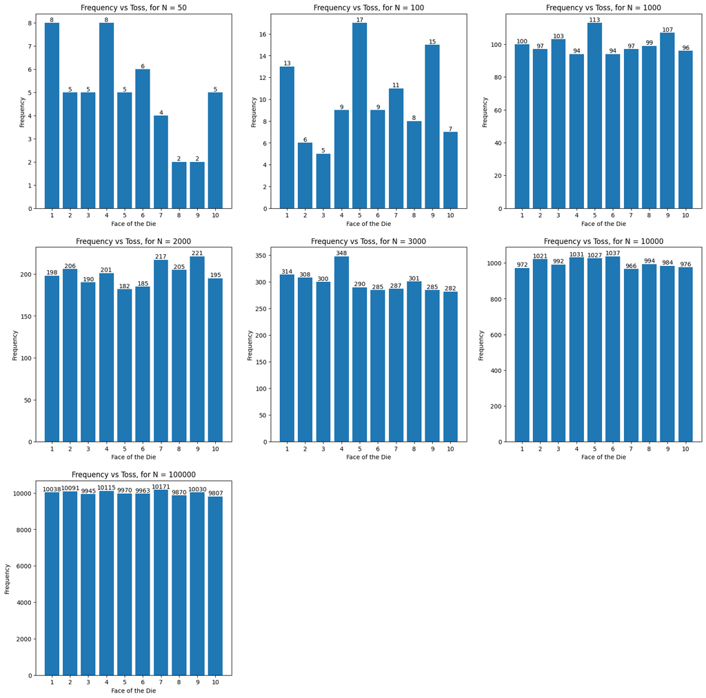

```
Estimated probabilities of getting an odd number:[0.48, 0.61, 0.52, 0.504, 0.492, 0.4941, 0.50154]
```

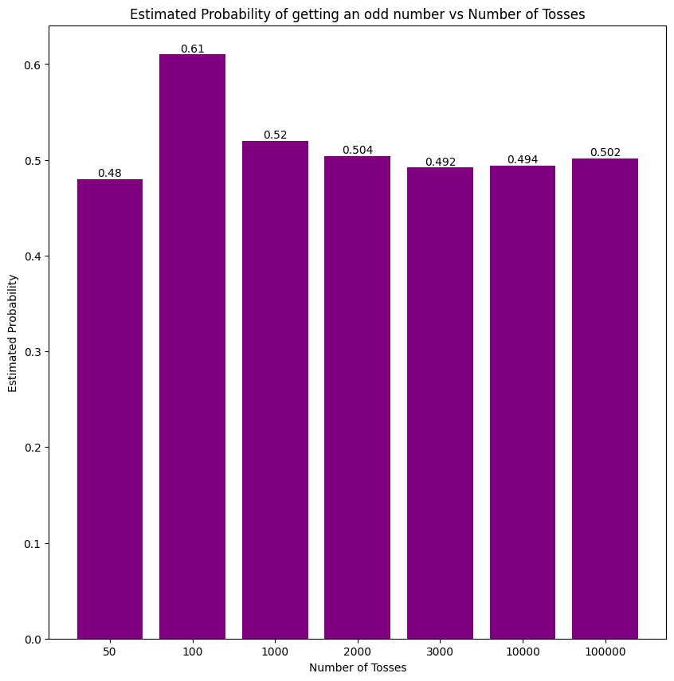

```python
# Answer:
seed() # set the np seed
# Simulate the tossing of a 10 sided die for t=50, 100, 1000, 2000, 3000, 10000 and 100000 tosses
def simulate_tossing(tosses): # toss a 10 sided die and return the results in a list depicting the frequency of each toss
    results = [0]*10
    for i in range(tosses):
        results[np.random.randint(0,10)] += 1
    return results

tosses = [50, 100, 1000, 2000, 3000, 10000, 100000] # number of tosses
results = [simulate_tossing(toss) for toss in tosses] # results of each toss
# Write the results nicely
print("Results of simulating values for a fair 10 sided die:")
for i in range(len(results)):
    display(Markdown("For " + str(tosses[i]) + " tosses, the results are: " + str(results[i]) + " and the estimated probability of getting an odd number is: **" + str(sum([results[i][j] for j in range(10) if j%2 == 0])/sum(results[i])) + "**"))

# Plot the results of the simulation
plt.figure(figsize=(20,15))
fig, axs = plt.subplots(3, 3, figsize=(20, 20))
axs = axs.ravel()
for i in range(len(results)):
    axs[i].bar(range(1, len(results[i]) + 1), results[i])
    axs[i].set_title('Frequency vs Toss, for N = ' + str(tosses[i]))
    axs[i].set_xlabel('Face of the Die')
    axs[i].set_ylabel('Frequency')
    axs[i].set_xticks(range(1, len(results[i]) + 1))
    # Label the bars with the frequency
    for j in range(1, len(results[i]) + 1):
        axs[i].text(j, results[i][j-1], str(results[i][j-1]), ha='center', va='bottom')
# Before we show the plot, lets kill the empty plots
for i in range(len(results), len(axs)):
    fig.delaxes(axs[i])
plt.show()

# For each result in result, calculate the ratio between the number of odd tosses and the total number of tosses
estimated_probabilities = [sum([result[i] for i in range(10) if i%2 == 0])/sum(result) for result in results]
# Note we use %2 == 0 because we are counting from 0 in the index
print("Estimated probabilities of getting an odd number:" + str(estimated_probabilities))

# Plot the estimated probabilities against the number of tosses as a vertical bar chart
plt.figure(figsize=(10,10))
plt.bar(range(0, len(estimated_probabilities)), estimated_probabilities, color='purple')
plt.xticks(range(len(estimated_probabilities)), tosses)
plt.title('Estimated Probability of getting an odd number vs Number of Tosses')
plt.xlabel('Number of Tosses')
plt.ylabel('Estimated Probability')
# label the bars with the estimated probabilities
for i in range(len(estimated_probabilities)):
    plt.text(i, estimated_probabilities[i], str(round(estimated_probabilities[i], 3)), ha='center', va='bottom')
plt.show()
```

(b) Suppose X is a random variable denoting the outcome of a die toss. Based on mathematical analysis and probability theory, what is the probability that X has an odd value?

Answer:

The PMF of the RV X is a discrete uniform distribution with 10 equally likely outcomes.

The PMF of X is given by: $ f_X(x) = \begin{cases} \frac{1}{10} & \text{if } 0 \leq x \leq 10 \\ 0 & \text{otherwise} \end{cases} $

The probability of obtaining an odd number is given by: $P(1) + P(3) + P(5) + P(7) + P(9) = \frac{1}{10}*5 = \frac{1}{2}$

Therefore the probability of obtaining an odd number is 0.5.

(c) Refer back to part (a). Does it agree with the theoretical result in (b)?

```
Percentage error between the estimated and theoretical probabilities:
```

For 50 tosses, the error is: **4.0 %**

For 100 tosses, the error is: **22.0 %**

For 1000 tosses, the error is: **4.0 %**

For 2000 tosses, the error is: **0.8 %**

For 3000 tosses, the error is: **1.6 %**

For 10000 tosses, the error is: **1.18 %**

For 100000 tosses, the error is: **0.308 %**

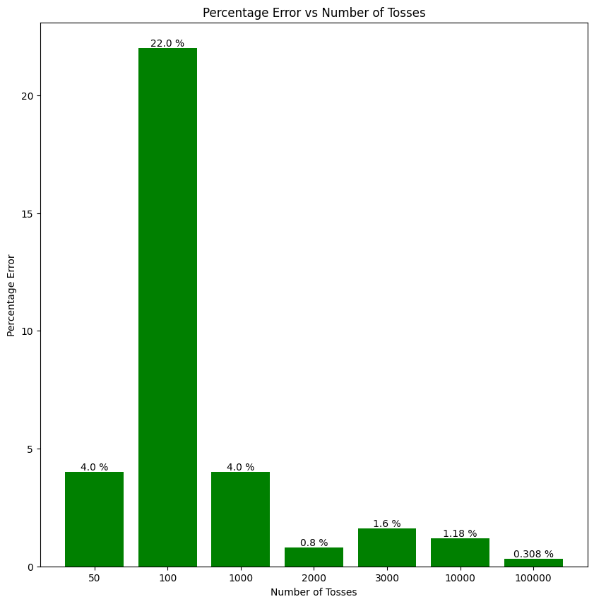

```python
# Answer:
seed() # set the np seed
# Calculate % error between simulated and theoretical probabilities
theoretical_probabilities = [0.5]*len(estimated_probabilities)
error = [100*abs(estimated_probabilities[i] - theoretical_probabilities[i])/theoretical_probabilities[i] for i in range(len(estimated_probabilities))]
# print the errors nicely
print("Percentage error between the estimated and theoretical probabilities:")
for i in range(len(error)):
    display(Markdown("For " + str(tosses[i]) + " tosses, the error is: **" + str(round(error[i], 3)) + " %**"))

# Plot the error against the number of tosses as a vertical bar chart
plt.figure(figsize=(10,10))
plt.bar(range(len(error)), error, color='green')
plt.xticks(range(len(error)), tosses)
plt.title('Percentage Error vs Number of Tosses')
plt.xlabel('Number of Tosses')
plt.ylabel('Percentage Error')
for i in range(len(error)):
    plt.text(i, error[i], str(round(error[i], 3)) + " %", ha='center', va='bottom')
plt.show()
```

Answer:

Based on the % error calculations above, the theoretical result in (b) agrees with the simulation results in (a). The % errors are 4.0%, 22.0%, 0.8%, 1.6%, 1.18% and 0.308%. Apart from the % Error for n = 100, all the other % errors are less than 5%. In fact, the % error for n = 100000 is less than 0.5%.

Therefore, it is safe to say that the theoretical result in (b) agrees with the simulation results in (a).

(d) Repeat parts (a), (b), and (c) with a 10-sided die that has the property that any odd number is twice as likely as an even number and all even numbers are equally likely.

```
Results of simulating values for an unfair 10 sided die:
```

For 50 tosses, the results are: [6, 3, 3, 6, 8, 0, 8, 6, 5, 5] and the probability of getting an odd number is: **0.6**

For 100 tosses, the results are: [15, 8, 11, 6, 15, 10, 8, 6, 15, 6] and the probability of getting an odd number is: **0.64**

For 1000 tosses, the results are: [150, 78, 128, 73, 132, 54, 145, 77, 112, 51] and the probability of getting an odd number is: **0.667**

For 2000 tosses, the results are: [273, 134, 266, 117, 281, 123, 282, 122, 286, 116] and the probability of getting an odd number is: **0.694**

For 3000 tosses, the results are: [404, 202, 395, 197, 383, 193, 396, 233, 395, 202] and the probability of getting an odd number is: **0.658**

For 10000 tosses, the results are: [1318, 625, 1338, 682, 1352, 673, 1337, 659, 1340, 676] and the probability of getting an odd number is: **0.668**

For 100000 tosses, the results are: [13433, 6680, 13311, 6618, 13408, 6608, 13032, 6832, 13368, 6710] and the probability of getting an odd number is: **0.666**

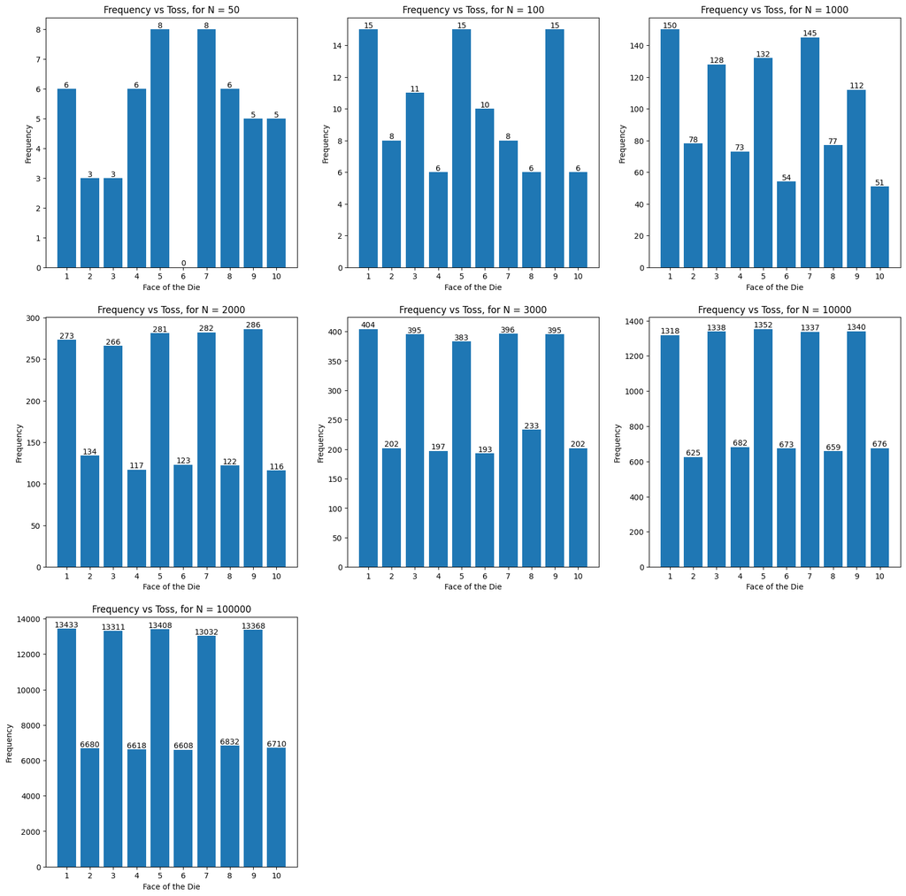

```
Estimated probabilities of getting an odd number:[0.6, 0.64, 0.667, 0.694, 0.6576666666666666, 0.6685, 0.66552]
```

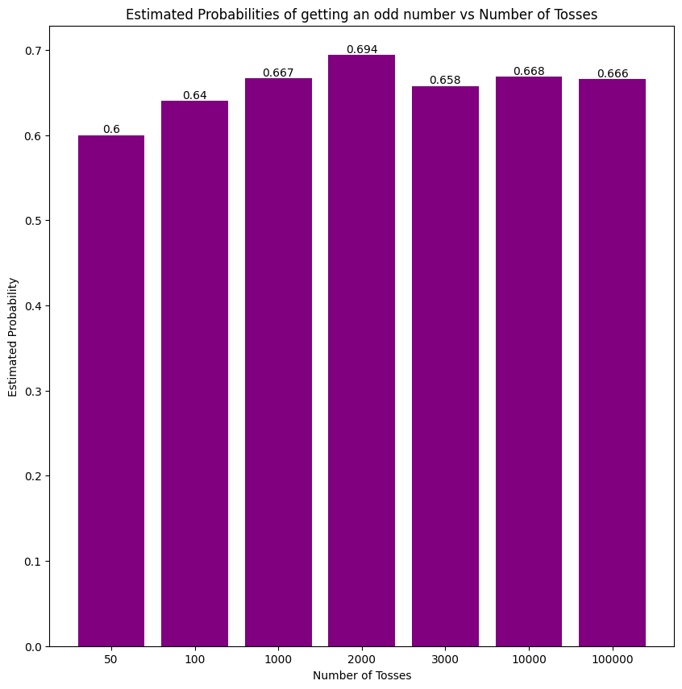

```python
# Answer:
seed() # set the np seed
# Simulate the tossing of a 10 sided die for t=50, 100, 1000, 2000, 3000, 10000 and 100000 tosses
def simulate_unfair_tossing(tosses): # toss a 10 sided die and return the results in a list depicting the frequency of each toss
    results = [0]*10
    for i in range(tosses):
        # we need the probability of each toss to be 2/15, 1/15, 2/15, 1/15, 2/15, 1/15, 2/15, 1/15, 2/15, 1/15
        results[np.random.choice([0,1,2,3,4,5,6,7,8,9],p=[2/15,1/15,2/15,1/15,2/15,1/15,2/15,1/15,2/15,1/15])] += 1
    return results

tosses = [50, 100, 1000, 2000, 3000, 10000, 100000] # number of tosses
results = [simulate_unfair_tossing(toss) for toss in tosses] # results of each toss
# Write the results nicely
print("Results of simulating values for an unfair 10 sided die:")
for i in range(len(results)):
    display(Markdown("For " + str(tosses[i]) + " tosses, the results are: " + str(results[i]) + " and the probability of getting an odd number is: **" + str(round(sum([results[i][j] for j in range(10) if j%2 == 0])/sum(results[i]), 3)) + "**"))


# Plot the results of the simulation
plt.figure(figsize=(20,15))
fig, axs = plt.subplots(3, 3, figsize=(20, 20))
axs = axs.ravel()
for i in range(len(results)):
    axs[i].bar(range(1, len(results[i]) + 1), results[i])
    axs[i].set_title('Frequency vs Toss, for N = ' + str(tosses[i]))
    axs[i].set_xlabel('Face of the Die')
    axs[i].set_ylabel('Frequency')
    axs[i].set_xticks(range(1, len(results[i]) + 1))
    # Label the bars with the frequency
    for j in range(1, len(results[i]) + 1):
        axs[i].text(j, results[i][j-1], str(results[i][j-1]), ha='center', va='bottom')
# Before we show the plot, lets kill the empty plots
for i in range(len(results), len(axs)):
    fig.delaxes(axs[i])
plt.show()

# For each result in result, calculate the ratio between the number of odd tosses and the total number of tosses
estimated_probabilities = [sum([result[i] for i in range(10) if i%2 == 0])/sum(result) for result in results]
# Note we use %2 == 0 because we are counting from 0 in the index
print("Estimated probabilities of getting an odd number:" + str(estimated_probabilities))

# Plot the estimated probabilities against the number of tosses as a vertical bar chart
plt.figure(figsize=(10,10))
plt.bar(range(0, len(estimated_probabilities)), estimated_probabilities, color='purple')
plt.xticks(range(len(estimated_probabilities)), tosses)
plt.title('Estimated Probabilities of getting an odd number vs Number of Tosses')
plt.xlabel('Number of Tosses')
plt.ylabel('Estimated Probability')
# label the bars with the estimated probabilities
for i in range(len(estimated_probabilities)):
    plt.text(i, estimated_probabilities[i], str(round(estimated_probabilities[i], 3)), ha='center', va='bottom')
plt.show()
```

The probability of obtaining an odd number is given by: $P(1) + P(3) + P(5) + P(7) + P(9) = \frac{2}{15}*5 = \frac{2}{3}$

Therefore the probability of obtaining an odd number is $\frac{2}{3}$.

```
Percentage error between the estimated and theoretical probabilities:
```

For 50 tosses, the error is: **10.0%**

For 100 tosses, the error is: **4.0%**

For 1000 tosses, the error is: **0.05%**

For 2000 tosses, the error is: **4.1%**

For 3000 tosses, the error is: **1.35%**

For 10000 tosses, the error is: **0.275%**

For 100000 tosses, the error is: **0.172%**

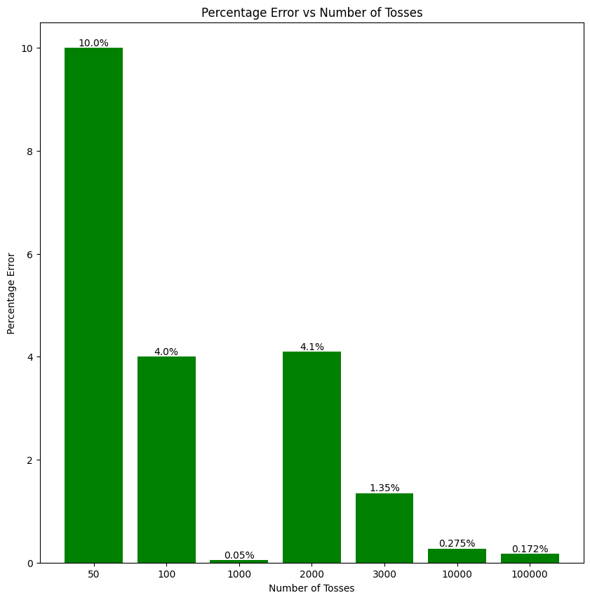

```python
# Calculate % error between simulated and theoretical probabilities
seed() # set the np seed
theoretical_probabilities = [2/3]*len(estimated_probabilities)
error = [100*abs(estimated_probabilities[i] - theoretical_probabilities[i])/theoretical_probabilities[i] for i in range(len(estimated_probabilities))]
# print the errors nicely
print("Percentage error between the estimated and theoretical probabilities:")
for i in range(len(error)):
    display(Markdown("For " + str(tosses[i]) + " tosses, the error is: **" + str(round(error[i], 3)) + "%**"))

# Plot the error against the number of tosses as a vertical bar chart
plt.figure(figsize=(10,10))
plt.bar(range(len(error)), error, color='green')
plt.xticks(range(len(error)), tosses)
plt.title('Percentage Error vs Number of Tosses')
plt.xlabel('Number of Tosses')
plt.ylabel('Percentage Error')
for i in range(len(error)):
    plt.text(i, error[i], str(round(error[i], 3)) + "%", ha='center', va='bottom')
plt.show()
```

Answer:

Based on the % error calculations above, the theoretical result agrees with the simulation results. The % errors are 10.0%, 4.0%, 0.05%, 4.1%, 1.35%. 0.275%, 0.172%. Apart from the % Error for n = 50, all the other % errors are less than 5%. In fact, the % error for n = 100000 is less than 0.2%.

### 2. (25 pts) *Maximum Likelihood Estimation*.

Consider the data sequence ${x_1, x_2, . . . , x_n}$, of length n = 100000 provided in the file “data.txt”. It is known that the data is normally distributed. However, the mean $\mu$ and the variance $\sigma^2$ of this normal distribution is unknown. In this problem, you are required to estimate µ and σ using methods learned in the course. Assume that the data points are i.i.d. random variables $X_1, X_2, X_3 ... X_n$ where each $X_i$ ~ $\mathcal{N}(\mu, \sigma^2)$. The data set ${x_1, x_2, . . . , x_n}$ provided in the file “data.txt” are the observed values of these random variables. You will determine $\mu$ and $\sigma$ for the data so that the data matches to its most likely Gaussian bell curve. Mathematically, you determine $\mu$ and $\sigma$ that maximize the probability of observing the data given the choice of $\mu$ and $\sigma$. Let $f_{X_1}, f_{X_2}, . . . , f_{X_n}(x_1,x_2,x_3...x_n|\mu,\sigma)$ be the joint density of the RVs $X_1, X_2, X_3 ... X_n$ evaluated at our data points ${x_1, x_2, . . . , x_n}$ given our choice of $\mu$ and $\sigma$. The maximum likelihood estimates $\mu_{MLE}$ and $\sigma_{MLE}$ for $\mu$ and $\sigma$ are found as follows:

$$\mu_{MLE} = argmax_{\mu} log(f_{X_1}, f_{X_2}, . . . , f_{X_n}(x_1,x_2,x_3...x_n|\mu,\sigma))$$$$\sigma_{MLE} = argmax_{\sigma} log(f_{X_1}, f_{X_2}, . . . , f_{X_n}(x_1,x_2,x_3...x_n|\mu_{MLE},\sigma))$$

(a) Analytically show that: $$log(f_{x_1,x_2...x_n}(x_1,x_2...x_n|\mu,\sigma)) = -\frac{n}{2}log(2\pi\sigma^2)-\sum\limits_{i=1}^n\frac{(x_i-\mu)^2}{2\sigma^2}$$

Answer: $$\log(f_{X_1,X_2,...,X_n}(x_1,x_2,...,x_n|\mu,\sigma))$$ $$= \log\left(\prod\limits_{i=1}^n \frac{1}{\sqrt{2\pi\sigma^2}}e^{-\frac{(x_i-\mu)^2}{2\sigma^2}}\right)$$ $$= \sum\limits_{i=1}^n \log\left(\frac{1}{\sqrt{2\pi\sigma^2}}e^{-\frac{(x_i-\mu)^2}{2\sigma^2}}\right)$$ $$= \sum\limits_{i=1}^n \left[\log\left(\frac{1}{\sqrt{2\pi\sigma^2}}\right)-\frac{(x_i-\mu)^2}{2\sigma^2}\right]$$ $$= \sum\limits_{i=1}^n \left[-\frac{1}{2}\log(2\pi\sigma^2)-\frac{(x_i-\mu)^2}{2\sigma^2}\right]$$ $$= -\frac{n}{2}\log(2\pi\sigma^2)-\sum\limits_{i=1}^n\frac{(x_i-\mu)^2}{2\sigma^2}$$

Therefore we have proved that $$log(f_{x_1,x_2...x_n}(x_1,x_2...x_n|\mu,\sigma)) = -\frac{n}{2}log(2\pi\sigma^2)-\sum\limits_{i=1}^n\frac{(x_i-\mu)^2}{2\sigma^2}$$

(b) Find analytical expressions for $\mu_{MLE}$ and $\sigma_{MLE}$ in terms of the data $x_1, x_2, ..., x_n$ by using the equation derived in (a) in the equations for $\mu_{MLE}$ and $\sigma_{MLE}$. For the data provided in `’data.txt’`, find the values of $\mu_{MLE}$ and $\sigma_{MLE}$ using the analytical expressions derived.

Answer:

To find $\mu_{MLE}$ we start with: $$\mu_{MLE} = argmax_{\mu} log(f_{X_1}, f_{X_2}, . . . , f_{X_n}(x_1,x_2,x_3...x_n|\mu,\sigma))$$ To maximize with respect to $\mu$, we take the derivative of the log-likelihood function with respect to $\mu$ and set it equal to 0. $$\frac{d}{d\mu}log(f_{X_1}, f_{X_2}, . . . , f_{X_n}(x_1,x_2,x_3...x_n|\mu,\sigma))=0$$ $$=\frac{d}{d\mu}\left(-\frac{n}{2}\log(2\pi) - n\log(\sigma) - \frac{1}{2\sigma^2}\sum_{i=1}^{n} (x_i - \mu)^2\right)=0$$ $$=\frac{d}{d\mu}\left(- \frac{1}{2\sigma^2}\sum_{i=1}^{n} (x_i - \mu)^2\right)=0$$ $$=-\frac{1}{2\sigma^2}\frac{d}{d\mu}\sum_{i=1}^{n} (x_i - \mu)^2=0$$ $$=-\frac{1}{2\sigma^2}\sum_{i=1}^{n} 2(x_i - \mu)=0$$ $$=\frac{1}{\sigma^2}\sum_{i=1}^{n} (x_i - \mu)=0$$ $$\sum_{i=1}^{n} (x_i) - n\mu=0$$ $$\mu_{MLE}=\frac{1}{n}\sum_{i=1}^{n} x_i$$

Similarly, to find $\sigma_{MLE}$ we start with: $$\sigma_{MLE} = argmax_{\sigma} log(f_{X_1}, f_{X_2}, . . . , f_{X_n}(x_1,x_2,x_3...x_n|\mu_{MLE},\sigma))$$ To maximize with respect to $\sigma$, we take the derivative of the log-likelihood function with respect to $\sigma$ and set it equal to 0. $$\frac{d}{d\sigma}log(f_{X_1}, f_{X_2}, . . . , f_{X_n}(x_1,x_2,x_3...x_n|\mu_{MLE},\sigma))=0$$ $$=\frac{d}{d\sigma}\left(-\frac{n}{2}\log(2\pi) - n\log(\sigma) - \frac{1}{2\sigma^2}\sum_{i=1}^{n} (x_i - \mu_{MLE})^2\right)=0$$ $$=\frac{d}{d\sigma}\left(-n\log(\sigma)-\frac{1}{2\sigma^2}\sum\limits_{i=1}^n(x_i-\mu_{MLE})\right)=0$$ $$=-n\frac{d}{d\sigma}\log(\sigma)-\frac{d}{d\sigma}\frac{1}{2\sigma^2}\sum\limits_{i=1}^n(x_i-\mu_{MLE})^2=0$$ $$=-n\frac{1}{\sigma}+\frac{1}{\sigma^3}\sum\limits_{i=1}^n(x_i-\mu_{MLE})^2=0$$ $$\frac{n}{\sigma}= \frac{1}{\sigma^3}\sum\limits_{i=1}^n(x_i-\mu_{MLE})^2$$ $$\sigma^2=\frac{1}{n}\sum\limits_{i=1}^n(x_i-\mu_{MLE})^2$$ $$\sigma_{MLE}=\sqrt{\frac{1}{n}\sum\limits_{i=1}^n(x_i-\mu_{MLE})^2}$$

```python
seed() # set the np seed
# Using the formulas above that we derived for \mu_{MLE} and \sigma_{MLE},
# \mu_{MLE} = \frac{1}{n}\sum_{i=1}^{n}x_{i}
# \sigma_{MLE} = \sqrt{\frac{1}{n}\sum_{i=1}^{n}(x_{i}-\mu_{MLE})^{2}}
data = []
with open('data.txt', 'r') as f:
    for line in tqdm.tqdm(f):
        data.append(float(line))

# Calculate the MLE for the mean and standard deviation
mu_MLE = sum(data)/len(data)
sigma_MLE = np.sqrt(sum([(x-mu_MLE)**2 for x in data])/len(data))
# Using latex, display the MLE for the mean and standard deviation
display(Markdown("Using Maximum Likelihood Estimation, we obtained:"))
display(Latex(r'$\mu_{MLE}$ = ' + str(round(mu_MLE, 1))))
display(Latex(r'$\sigma_{MLE}$ = ' + str(round(sigma_MLE, 1))))
```

```
100000it [00:00, 1470581.39it/s]
```

Using Maximum Likelihood Estimation, we obtained:

$\mu_{MLE}$ = 20.0

$\sigma_{MLE}$ = 10.0

(c) Plot the PDF of $X_i$ by plotting the histogram of the data ${x_1, x_2, ..., x_n}$ in `’data.txt’`. For the $\mu_{MLE}$ and $\sigma_{MLE}$ obtained in (b), superimpose the histogram with the PDF of a Gaussian random variable with mean $\mu_{MLE}$ and variance $\sigma_{MLE}^2$.

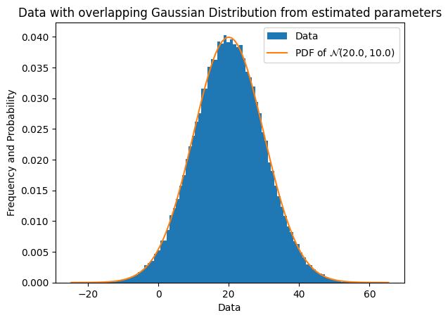

```python
# Answer:
seed() # set the np seed
# Plot the data as a density plot with 100 bins
plt.hist(data, bins=100, density=True, label='Data')
plt.xlabel('Data')
plt.ylabel('Frequency and Probability')
# Plot a Gaussian distribution with mean: mu_MLE and standard deviation: sigma_MLE
x = np.linspace(min(data), max(data), 100)
plt.plot(x, gaussian(x, mu_MLE, sigma_MLE), label= 'PDF of ' + r'$\mathcal{N}(%.1f, %.1f)$' % (mu_MLE, sigma_MLE))
# plt.title('Gaussian Distribution with ' + r'$\mathcal{N}(%.1f, %.1f)$' % (mu_MLE, sigma_MLE))
plt.title('Data with overlapping Gaussian Distribution from estimated parameters')
plt.legend()
plt.show()
```

### 3. (25 pts) *Naive Bayes Classifier*.

To maximize profit, advertisement companies like Google, Facebook, and Amazon want to target their advertisement to each user. Specifically, given a user and a product to sell, they want to determine whether this user will buy it. In this problem, we will build a classifier to help us determine whether a user will buy a certain product by using historical data.

Some demographic data is collected for 887 users and are provided in user data.csv. This dataset has four fields: i) Whether this user bought the product (1 for did buy and 0 for did not buy), ii) Type of Spender (1 for larger spender, 2 for medium spender, 3 for small spender) iii) Sex of user (1 for Male and 0 for Female), iv) Age of user. We use random variables B, T, S, and A for bought status, type of spender, sex, and age, respectively. In this problem, we are going to build a popular Naive Bayes Classifier to predict B given T, S, and A.

(a) Estimate the individual PMFs for B, T, S, and A by finding the fraction of each realization of these random variables among all data. Plot these PMFs (i.e. 4 PMFs in total).

The PMF of B is:

$P(B) = \begin{cases}\frac{545}{887}\text{ if } B = 0\\\frac{342}{887}\text{ if } B = 1\\\end{cases}$

The PMF of T is:

$P(T) = \begin{cases}\frac{228}{887}\text{ if } T = 1\\\frac{184}{887}\text{ if } T = 2\\\frac{475}{887}\text{ if } T = 3\\\end{cases}$

The PMF of S is:

$P(S) = \begin{cases}\frac{573}{887}\text{ if } S = 0\\\frac{314}{887}\text{ if } S = 1\\\end{cases}$

```
We will skip writing the PMF of A because has too many unique values.
```

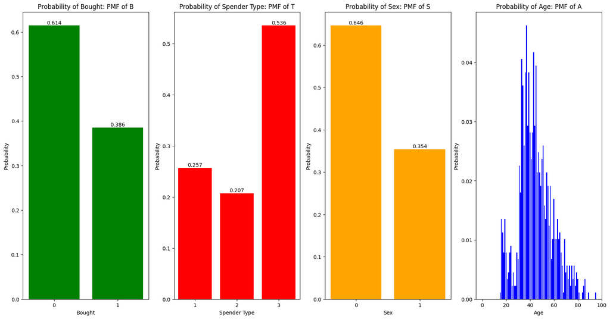

```python
# Answer:
seed() # set the np seed
# Import the data from user_data.csv
data = pd.read_csv('user_data.csv')
# There are 4 columns: B: Bought, T: Spender Type, S: Sex, A: Age
B = data['Bought']
T = data['Spender Type']
S = data['Sex']
A = data['Age']
# Plot the columns
plt.figure(figsize=(20,10))


plt.subplot(1,4,1)
plt.hist(B, bins=[-0.5 + i for i in range(max(B.value_counts().index) + 2)], density=True, rwidth=0.8, color='green')
# This plots the frequency of each value in B, but we want the probability
# So we divide the frequency by the total number of values in B
plt.xticks([0, 1])
plt.title('Probability of Bought: PMF of B')
plt.xlabel('Bought')
plt.ylabel('Probability')
# Label the bars with the probability
pmf_b = r'$P(B) = \begin{cases}'
for i in sorted(B.value_counts().index):
    plt.text(i, B.value_counts()[i]/len(B), str(round(B.value_counts()[i]/len(B), 3)), ha='center', va='bottom')
    pmf_b += r'\frac{' + str(B.value_counts()[i]) + r'}{' + str(len(B)) + r'}' + r'\text{ if } B = ' + str(i) + r'\\'
pmf_b += r'\end{cases}$'
display(Markdown("The PMF of B is:"))
display(Latex(pmf_b))


plt.subplot(1,4,2)
plt.hist(T, bins=[0.5 + i for i in range(max(T.value_counts().index) + 2)], density=True, rwidth=0.8, color='red')
plt.xticks([1, 2, 3])
plt.xlim(0.5, 3.5)
plt.title('Probability of Spender Type: PMF of T')
plt.xlabel('Spender Type')
plt.ylabel('Probability')
# Label the bars with the probability
pmf_t = r'$P(T) = \begin{cases}'
for i in sorted(T.value_counts().index):
    plt.text(i, T.value_counts()[i]/len(T), str(round(T.value_counts()[i]/len(T), 3)), ha='center', va='bottom')
    pmf_t += r'\frac{' + str(T.value_counts()[i]) + r'}{' + str(len(T)) + r'}' + r'\text{ if } T = ' + str(i) + r'\\'
pmf_t += r'\end{cases}$'
display(Markdown("The PMF of T is:"))
display(Latex(pmf_t))


plt.subplot(1,4,3)
plt.hist(S, bins=[-0.5 + i for i in range(max(S.value_counts().index) + 2)], density=True, rwidth=0.8, color='orange')
plt.xticks([0, 1])
plt.title('Probability of Sex: PMF of S')
plt.xlabel("Sex")
plt.ylabel('Probability')
# Label the bars with the frequency
pmf_s = r'$P(S) = \begin{cases}'
for i in sorted(S.value_counts().index):
    plt.text(i, S.value_counts()[i]/len(S), str(round(S.value_counts()[i]/len(S), 3)), ha='center', va='bottom')
    pmf_s += r'\frac{' + str(S.value_counts()[i]) + r'}{' + str(len(S)) + r'}' + r'\text{ if } S = ' + str(i) + r'\\'
pmf_s += r'\end{cases}$'
display(Markdown("The PMF of S is:"))
display(Latex(pmf_s))

plt.subplot(1,4,4)
plt.hist(A, bins=[-0.5 + i for i in range(max(A.value_counts().index) + 2)], density=True, rwidth=0.8, color='blue')
plt.title('Probability of Age: PMF of A')
plt.xlabel('Age')
plt.ylabel('Probability')
# Label the bars with the frequency
# pmf_a = r'$P(A) = \begin{cases}'
# for i in sorted(A.value_counts().index):
#     plt.text(i, A.value_counts()[i], str(A.value_counts()[i]), ha='center', va='bottom')
#     pmf_a += str(A.value_counts()[i]) + r'\text{ if } A = ' + str(i) + r'\\'
# pmf_a += r'\end{cases}$'
# display(Markdown("The PMF of A is:"))
# display(Latex(pmf_a))
print("We will skip writing the PMF of A because has too many unique values.")

plt.show()
```

(b) We are interested in how T, S, and A affect B, in the context of the Naive Bayes Classifier; the first step is to estimate the conditional PMF conditioning on the outcome of interest, i.e., survival or not. Estimate and plot the conditional PMFs for T, S, and A separately conditioned on B = 1 and B = 0 (i.e. 6 PMFs in total).

The PMF of T|B=0 is:

$P(T|B=0) = \begin{cases}\frac{92}{545}\text{ if } T = 1\\\frac{105}{545}\text{ if } T = 2\\\frac{348}{545}\text{ if } T = 3\\\end{cases}$

The PMF of T|B=1 is:

$P(T|B=1) = \begin{cases}\frac{136}{342}\text{ if } T = 1\\\frac{79}{342}\text{ if } T = 2\\\frac{127}{342}\text{ if } T = 3\\\end{cases}$

The PMF of S|B=0 is:

$P(S|B=0) = \begin{cases}\frac{462}{545}\text{ if } S = 0\\\frac{83}{545}\text{ if } S = 1\\\end{cases}$

The PMF of S|B=1 is:

$P(S|B=1) = \begin{cases}111\text{ if } S = 0\\231\text{ if } S = 1\\\end{cases}$

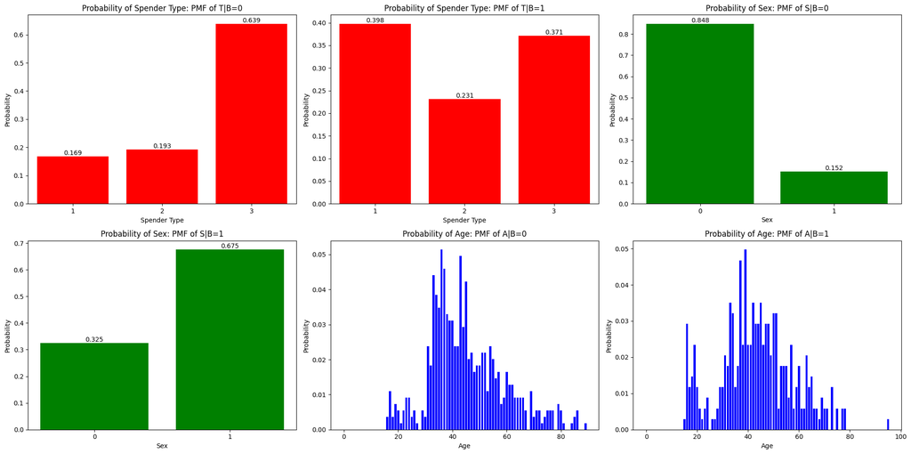

```python
# Answer:
seed() # set the np seed
# Our variables are formatted as follows: A_x represents P(A|B=x) = P(A and B=x)/P(B=x)
T_0 = T[B == 0]
T_1 = T[B == 1]
A_0 = A[B == 0]
A_1 = A[B == 1]
S_0 = S[B == 0]
S_1 = S[B == 1]
# For the above line, lets consider the matlab equivalent:
# T_0 = T(B == 0)
# Plot these conditional PMFs on subplots
plt.figure(figsize=(20,10))
plt.subplot(2,3,1)
plt.hist(T_0, bins=[0.5 + i for i in range(max(T_1.value_counts().index) + 2)], density=True, rwidth=0.8, color='red')
plt.xticks([1, 2, 3])
plt.xlim(0.5, 3.5)
plt.title('Probability of Spender Type: PMF of T|B=0')
plt.xlabel('Spender Type')
plt.ylabel('Probability')
# Label the bars with the frequency
pmf_t_0 = r'$P(T|B=0) = \begin{cases}'
for i in sorted(T_0.value_counts().index):
    plt.text(i, T_0.value_counts()[i]/len(T_0), str(round(T_0.value_counts()[i]/len(T_0), 3)), ha='center', va='bottom')
    pmf_t_0 += r'\frac{' + str(T_0.value_counts()[i]) + r'}{' + str(len(T_0)) + r'}' + r'\text{ if } T = ' + str(i) + r'\\'
pmf_t_0 += r'\end{cases}$'
display(Markdown("The PMF of T|B=0 is:"))
display(Latex(pmf_t_0))

plt.subplot(2,3,2)
plt.hist(T_1, bins=[0.5 + i for i in range(max(T_1.value_counts().index) + 2)], density=True, rwidth=0.8, color='red')
plt.xticks([1, 2, 3])
plt.xlim(0.5, 3.5)
plt.title('Probability of Spender Type: PMF of T|B=1')
plt.xlabel('Spender Type')
plt.ylabel('Probability')
# Label the bars with the frequency
pmf_t_1 = r'$P(T|B=1) = \begin{cases}'
for i in sorted(T_1.value_counts().index):
    plt.text(i, T_1.value_counts()[i]/len(T_1), str(round(T_1.value_counts()[i]/len(T_1), 3)), ha='center', va='bottom')
    pmf_t_1 += r'\frac{' + str(T_1.value_counts()[i]) + r'}{' + str(len(T_1)) + r'}' + r'\text{ if } T = ' + str(i) + r'\\'
pmf_t_1 += r'\end{cases}$'
display(Markdown("The PMF of T|B=1 is:"))
display(Latex(pmf_t_1))

plt.subplot(2,3,3)
plt.hist(S_0, bins=[-0.5 + i for i in range(max(S_0.value_counts().index) + 2)], density=True, rwidth=0.8, color='green')
plt.xticks([0, 1])
plt.xlim(-0.5, 1.5)
plt.title('Probability of Sex: PMF of S|B=0')
plt.xlabel('Sex')
plt.ylabel('Probability')
# Label the bars with the frequency
pmf_s_0 = r'$P(S|B=0) = \begin{cases}'
for i in sorted(S_0.value_counts().index):
    plt.text(i, S_0.value_counts()[i]/len(S_0), str(round(S_0.value_counts()[i]/len(S_0), 3)), ha='center', va='bottom')
    pmf_s_0 += r'\frac{' + str(S_0.value_counts()[i]) + r'}{' + str(len(S_0)) + r'}' + r'\text{ if } S = ' + str(i) + r'\\'
pmf_s_0 += r'\end{cases}$'
display(Markdown("The PMF of S|B=0 is:"))
display(Latex(pmf_s_0))

plt.subplot(2,3,4)
plt.hist(S_1, bins=[-0.5 + i for i in range(max(S_1.value_counts().index) + 2)], density=True, rwidth=0.8, color='green')
plt.xticks([0, 1])
plt.title('Probability of Sex: PMF of S|B=1')
plt.xlabel('Sex')
plt.ylabel('Probability')
# Label the bars with the frequency
pmf_s_1 = r'$P(S|B=1) = \begin{cases}'
for i in sorted(S_1.value_counts().index):
    plt.text(i, S_1.value_counts()[i]/len(S_1), str(round(S_1.value_counts()[i]/len(S_1), 3)), ha='center', va='bottom')
    pmf_s_1 += str(S_1.value_counts()[i]) + r'\text{ if } S = ' + str(i) + r'\\'
pmf_s_1 += r'\end{cases}$'
display(Markdown("The PMF of S|B=1 is:"))
display(Latex(pmf_s_1))

plt.subplot(2,3,5)
plt.hist(A_0, bins=[-0.5 + i for i in range(max(A_0.value_counts().index) + 2)], density=True, rwidth=0.8, color='blue')
plt.title('Probability of Age: PMF of A|B=0')
plt.xlabel('Age')
plt.ylabel('Probability')

plt.subplot(2,3,6)
plt.hist(A_1, bins=[-0.5 + i for i in range(max(A_1.value_counts().index) + 2)], density=True, rwidth=0.8, color='blue')
plt.title('Probability of Age: PMF of A|B=1')
plt.xlabel('Age')
plt.ylabel('Probability')

plt.tight_layout()
plt.show()
```

(c) In the Naive Bayes Classifier, we use the conditional independence assumption. For example, if T, S, and A are conditionally independent on B, then P(T, S, A|B = 0) = P(T|B = 0)P(S|B = 0)P(A|B = 0) and P(T, S, A|B = 1) = P(T|B = 1)P(S|B = 1)P(A|B = 1). Using this assumption, compute P(B = 0, T = 1, S = 0, A ≤ 55) and P(B = 1, T = 1, S = 0, A ≤ 55) based on your estimations in (a) and (b).

```python
# Answer:
seed() # set the np seed
# Assuming that they are conditionally independent, we can use the formula:
# P(B = 0, T = 1, S = 0, A ≤ 55) = P(B = 0)P(T = 1|B = 0)P(S = 0|B = 0)P(A ≤ 55|B = 0)
# P(B = 1, T = 1, S = 0, A ≤ 55) = P(B = 1)P(T = 1|B = 1)P(S = 0|B = 1)P(A ≤ 55|B = 1)
# Lets compute and print the values:
B_0 = B[B == 0]
B_1 = B[B == 1]
p_b_0 = len(B_0) / len(B)
p_b_1 = len(B_1) / len(B)
p_t_1_b_0 = T_0.value_counts()[1] / len(T_0)
p_t_1_b_1 = T_1.value_counts()[1] / len(T_1)
p_s_0_b_0 = S_0.value_counts()[0] / len(S_0)
p_s_0_b_1 = S_1.value_counts()[0] / len(S_1)
p_a_l55_b_0 = len(A_0[A_0 <= 55]) / len(A_0)
p_a_l55_b_1 = len(A_1[A_1 <= 55]) / len(A_1)
p_b_0_t_1_s_0_a_l55 = p_b_0 * p_t_1_b_0 * p_s_0_b_0 * p_a_l55_b_0
p_b_1_t_1_s_0_a_l55 = p_b_1 * p_t_1_b_1 * p_s_0_b_1 * p_a_l55_b_1
print('P(B = 0, T = 1, S = 0, A <= 55) =', p_b_0_t_1_s_0_a_l55)
print('P(B = 1, T = 1, S = 0, A <= 55) =', p_b_1_t_1_s_0_a_l55)
```

```
P(B = 0, T = 1, S = 0, A <= 55) = 0.06969424622052946
P(B = 1, T = 1, S = 0, A <= 55) = 0.04016013252538375
```

(d) Assuming the conditional independence assumption and using your result in (c), compute P(B = 0|T = 1, S = 0, A ≤ 55) and P(B = 1|T = 1, S = 0, A ≤ 55). Predict whether a female whose age is below 55 and who is a large spender will buy this product or not.

```python
# Answer:
seed() # set the np seed
# We are looking for the probability that B = 0 given T = 1, S = 0, A <= 55
# P(B = 0|T = 1, S = 0, A <= 55) = P(B = 0, T = 1, S = 0, A <= 55) / P(T = 1, S = 0, A <= 55)
p_b_0_t_1_s_0_a_l55 = p_b_0_t_1_s_0_a_l55 / (p_b_0_t_1_s_0_a_l55 + p_b_1_t_1_s_0_a_l55)
p_b_1_t_1_s_0_a_l55 = 1 - p_b_0_t_1_s_0_a_l55
print('P(B = 0|T = 1, S = 0, A <= 55) =', p_b_0_t_1_s_0_a_l55)
print('P(B = 1|T = 1, S = 0, A <= 55) =', p_b_1_t_1_s_0_a_l55)
print("We predict that a female who is under 55 years old and a large spender will " + ("not buy" if p_b_0_t_1_s_0_a_l55 > 0.5 else "buy") + " this product with probability: ", p_b_0_t_1_s_0_a_l55 if p_b_0_t_1_s_0_a_l55 > 0.5 else 1 - p_b_0_t_1_s_0_a_l55)
```

```
P(B = 0|T = 1, S = 0, A <= 55) = 0.6344239257110379
P(B = 1|T = 1, S = 0, A <= 55) = 0.3655760742889621
We predict that a female who is under 55 years old and a large spender will not buy this product with probability:  0.6344239257110379
```

### 4. (25 pts) *Central Limit Theorem*.

Let $X_1, X_2, ..., X_n$ be a sequence of i.i.d. random variables with finite mean $\mu$ and finite variance $\sigma^2$. Let $Z_n$ be the mean of the first $n$ random variables in the sequence: $$Z_n = \frac{1}{n}\sum_{i=1}^{n} X_i$$ In this problem, we will plot the PDF of $Z_n$ by generating t = 10^4 samples of $Z_n$ and plotting the histogram of the generated samples.

(a) Let $X_i$ for i = 1, 2, ... be a uniform continuous random variable taking values in the interval (3, 7). Write a program to plot the PDF of Z_n. Consider n = 1, 2, 3, 10, 30, 100 and compare your results across different $n$'s.

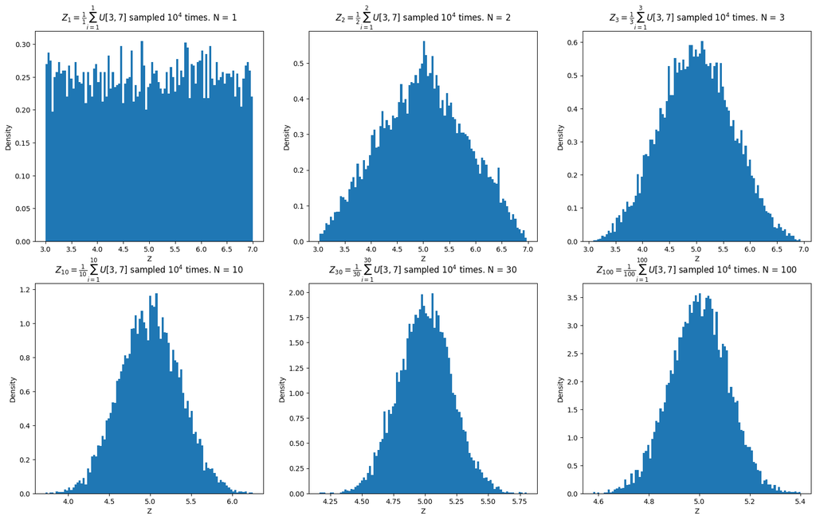

```python
# Answer:
seed() # set the np seed
ns = [1, 2, 3, 10, 30, 100]
# Plot as subplots
fig, axs = plt.subplots(2, 3, figsize=(20, 12))
axs = axs.ravel()
sampledZs = []
for i, n in enumerate(ns):
    sampledZ = np.sum(np.random.uniform(low=3, high=7, size=(10**4, n)), axis=1)*(1/n)
    sampledZs.append(sampledZ)
    axs[i].hist(sampledZ, bins=100, density=True)
    axs[i].set_title(r'$Z_{%d} = \frac{1}{%d}\sum_{i=1}^{%d} U[3, 7]$ sampled $10^4$ times. N = %d' % (n, n, n, n))
    axs[i].set_xlabel('Z')
    axs[i].set_ylabel('Density')
plt.show()
```

(b) Calculate analytically the mean and the variance of $X_i$ and of $Z_n$ in part (a).

Answer:

$X_i$ is U[3,7] so $E[X_i]=\frac{3+7}{2}=5$ and $Var[X_i]=\frac{(b-a)^2}{12}=\frac{4}{3}$

$Z_n$ is $\frac{1}{n}\sum_{i=1}^{n} X_i$ so $E[Z_n]=n\frac{1}{n}E[X_i]=5$ and $Var[Z_n]=n\frac{1}{n^2}\sum_{i=1}^{n} Var[X_i]=\frac{4}{3n}$

Expectations and Variances:

For $n=1$, $E[Z_1]=5$ and $Var[Z_1]=\frac{4}{3}$

For $n=2$, $E[Z_2]=5$ and $Var[Z_2]=\frac{4}{3}\frac{2}{2^2}=\frac{4}{6}$

For $n=3$, $E[Z_3]=5$ and $Var[Z_3]=\frac{4}{3}\frac{3}{3^2}=\frac{4}{9}$

For $n=10$, $E[Z_{10}]=5$ and $Var[Z_{10}]=\frac{4}{3}\frac{10}{10^2}=\frac{4}{30}$

For $n=30$, $E[Z_{30}]=5$ and $Var[Z_{30}]=\frac{4}{3}\frac{30}{30^2}=\frac{4}{90}$

For $n=100$, $E[Z_{100}]=5$ and $Var[Z_{100}]=\frac{4}{3}\frac{100}{100^2}=\frac{4}{300}$

(c) Write a program to generate a Gaussian random variable with the same mean and variance as $Z_n$. Superimpose its pdf on the plots from part (a).

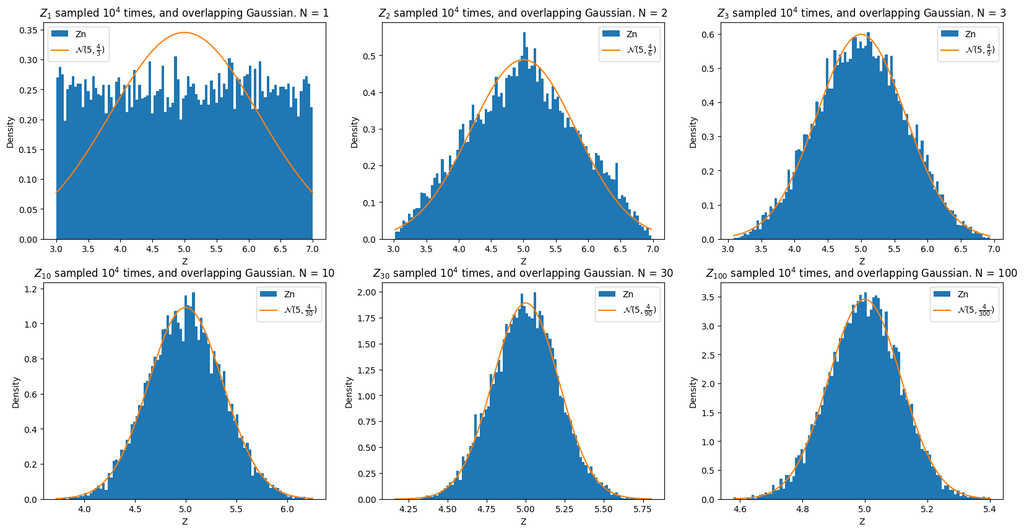

```python
# Answer:
seed() # set the np seed
fig, axs = plt.subplots(2, 3, figsize=(20, 10))
axs = axs.ravel()
for i, n in enumerate(ns):
    # We plot Zn
    axs[i].hist(sampledZs[i], bins=100, density=True, label='Zn')
    # Plot the Gaussian distribution with mean and standard deviation computed from the CLT
    x = np.linspace(min(sampledZs[i]), max(sampledZs[i]), 100)
    axs[i].plot(x, gaussian(x, 5, np.sqrt(4/(3*n))), label=r'$\mathcal{N}(5, \frac{4}{' + str(3*n) + r'})$')
    axs[i].set_title(r'$Z_{%d}$ sampled $10^4$ times, and overlapping Gaussian. N = %d' % (n, n))
    axs[i].set_xlabel('Z')
    axs[i].set_ylabel('Density')
    axs[i].legend()

plt.show()
```

(d) Repeat parts (a), (b), and (c) with Xi representing a toss of a 10-sided die that is described in Problem 1(d). Note that Xi and Zn are discrete in this case. Hence, we approximate the PDF of Zn by generating samples of Zn and plotting its histogram. Remark: In the case when $X_i$’s are discrete (which leads to discrete Zn), the upper faces of the rectangles forming the histogram of Zn converges toward a Gaussian PDF as n approaches infinity and hence even in this case, you should be able to observe the Central Limit Theorem.

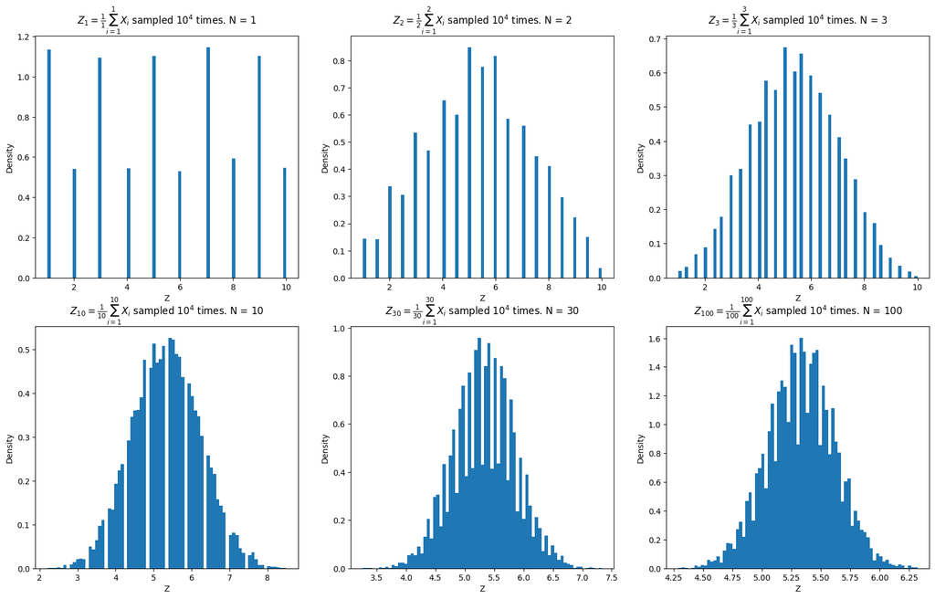

```python
# Answer:
seed() # set the np seed
ns = [1, 2, 3, 10, 30, 100]
# Now Xi = Dice with 10 sides, and Zn = (1/n) * sum(Xi)
fig, axs = plt.subplots(2, 3, figsize=(20, 12))
axs = axs.ravel()
sampledZs = []
for i, n in enumerate(ns):
    # X_i is now np.random.choice([0,1,2,3,4,5,6,7,8,9],p=[2/15,1/15,2/15,1/15,2/15,1/15,2/15,1/15,2/15,1/15])
    sampledZ = np.sum(np.random.choice([1,2,3,4,5,6,7,8,9,10], size=(10**4, n), p=[2/15,1/15,2/15,1/15,2/15,1/15,2/15,1/15,2/15,1/15]), axis=1)*(1/n)
    sampledZs.append(sampledZ)
    axs[i].hist(sampledZ, bins=75, density=True)
    axs[i].set_title(r'$Z_{%d} = \frac{1}{%d}\sum_{i=1}^{%d} X_i$ sampled $10^4$ times. N = %d' % (n, n, n, n))
    axs[i].set_xlabel('Z')
    axs[i].set_ylabel('Density')
plt.show()
```

Answer:

Lets first analytically calculate the mean and variance of $X_i$ and $Z_n$: $X_i$ is a 10 sided die where odd numbers are twice as likely as even numbers.

$\therefore E[X_i]=\frac{2}{15}(1+3+5+7+9)+\frac{1}{15}(2+4+6+8+10)= \frac{16}{3}$

$\therefore Var[X_i]=\frac{2}{15}(1^2+3^2+5^2+7^2+9^2)+\frac{1}{15}(2^2+4^2+6^2+8^2+10^2)-\frac{16}{3}^2=\frac{74}{9}$

$Z_n$ is $\frac{1}{n}\sum_{i=1}^{n} X_i$ so $E[Z_n]=n\frac{1}{n}E[X_i]=\frac{16}{3}$ and $Var[Z_n]=n\frac{1}{n^2}\sum_{i=1}^{n} Var[X_i]=\frac{74}{9n}$

For $n=1$, $E[Z_1]=\frac{16}{3}$ and $Var[Z_1]=\frac{74}{9}$

For $n=2$, $E[Z_2]=\frac{16}{3}$ and $Var[Z_2]=\frac{74}{9}\frac{2}{2^2}=\frac{37}{9}$

For $n=3$, $E[Z_3]=\frac{16}{3}$ and $Var[Z_3]=\frac{74}{9}\frac{3}{3^2}=\frac{74}{27}$

For $n=10$, $E[Z_{10}]=\frac{16}{3}$ and $Var[Z_{10}]=\frac{74}{9}\frac{10}{10^2}=\frac{37}{45}$

For $n=30$, $E[Z_{30}]=\frac{16}{3}$ and $Var[Z_{30}]=\frac{74}{9}\frac{30}{30^2}=\frac{37}{135}$

For $n=100$, $E[Z_{100}]=\frac{16}{3}$ and $Var[Z_{100}]=\frac{74}{9}\frac{100}{100^2}=\frac{37}{450}$

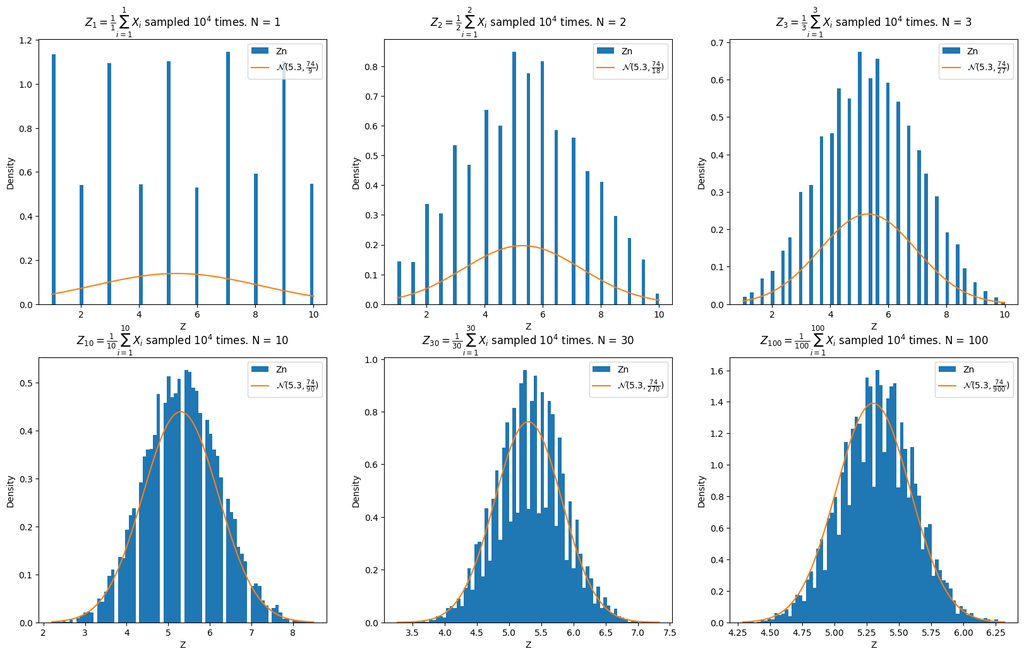

```python
# Answer:
seed() # set the np seed
ns = [1, 2, 3, 10, 30, 100]
# Now Xi = Dice with 10 sides, and Zn = (1/n) * sum(Xi)
fig, axs = plt.subplots(2, 3, figsize=(20, 12))
axs = axs.ravel()
sampledZs = []
for i, n in enumerate(ns):
    sampledZ = np.sum(np.random.choice([1,2,3,4,5,6,7,8,9,10], size=(10**4, n), p=[2/15,1/15,2/15,1/15,2/15,1/15,2/15,1/15,2/15,1/15]), axis=1)*(1/n)
    sampledZs.append(sampledZ)
    axs[i].hist(sampledZ, bins=75, density=True, label='Zn')
    axs[i].set_title(r'$Z_{%d} = \frac{1}{%d}\sum_{i=1}^{%d} X_{i}$ sampled $10^4$ times. N = %d' % (n, n, n, n))
    axs[i].set_xlabel('Z')
    axs[i].set_ylabel('Density')
    x = np.linspace(min(sampledZs[i]), max(sampledZs[i]), 100)
    axs[i].plot(x, gaussian(x, 5.3, np.sqrt(74/(9*n))), label=r'$\mathcal{N}(5.3, \frac{74}{' + str(9*n) + r'})$')
    axs[i].legend()
plt.show()
```

(e) (*Bonus 10 points*)

Repeat parts (a) and (c) with the same $X_i$ described in part (a), but this time compute and plot the exact PDF of $Z_n$ instead of generating samples. Provide full description of how you computed the exact PDF of $Z_n$.

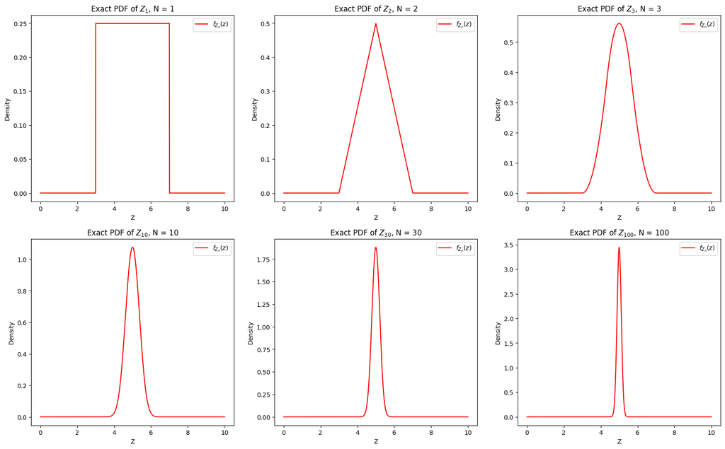

```python
# Answer:
seed() # set the np seed
ns = [1, 2, 3, 10, 30, 100]
# Xi = U[3, 7], and Zn = (1/n) * sum(Xi)
fig, axs = plt.subplots(2, 3, figsize=(20, 12))
axs = axs.ravel()
for i, n in enumerate(ns):
    # Generate the PDF of Xi
    x = np.linspace(0, 10, 1000)
    xi = lambda x: 0*(x<3) + (1/4)*(x>=3)*(x<=7)
    x_pdf = xi(x)
    z = np.linspace(0, 10, 1000)
    # Now we convolve z_pdf with x_pdf n times
    z_pdf = x_pdf
    for j in range(n-1):
        z_pdf = np.convolve(z_pdf, x_pdf)
    # Fix the x axis
    z = np.linspace(0, 10, len(z_pdf))
    # We need to normalize the PDF
    z_pdf = z_pdf/np.trapz(z_pdf, z)
    # We plot the PDF of Zn
    axs[i].plot(z, z_pdf, label=r'$f_{Z_n}(z)$', color='red')
    # Titles and labels and stuff
    axs[i].set_title(r'Exact PDF of $Z_{%d}$, N = %d' % (n, n))
    axs[i].set_xlabel('Z')
    axs[i].set_ylabel('Density')
    axs[i].legend()
plt.show()
```

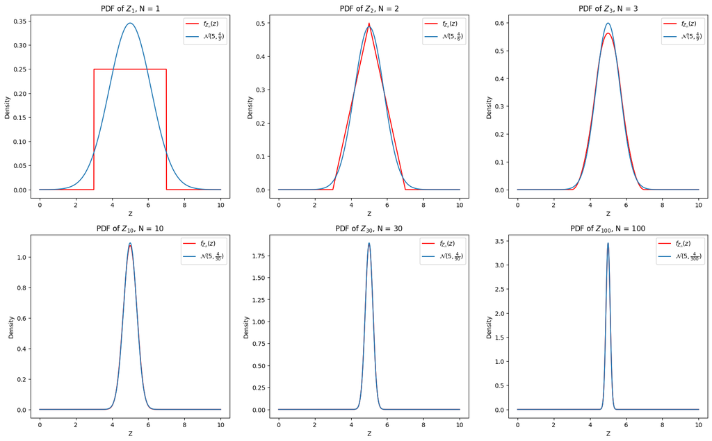

```python
# We do the same thing again except for we plot the exact PDF(the stuff above) along with the histogram with mean and standard deviation computed from the CLT

# Answer:
seed() # set the np seed
ns = [1, 2, 3, 10, 30, 100]

# Xi = U[3, 7], and Zn = (1/n) * sum(Xi)
fig, axs = plt.subplots(2, 3, figsize=(20, 12))
axs = axs.ravel()

for i, n in enumerate(ns):
    # Generate the PDF of Xi
    x = np.linspace(0, 10, 1000)
    xi = lambda x: 0*(x<3) + (1/4)*(x>=3)*(x<=7)
    x_pdf = xi(x)
    z = np.linspace(0, 10, 1000)
    # Now we convolve z_pdf with x_pdf n times
    z_pdf = x_pdf
    for j in range(n-1):
        z_pdf = np.convolve(z_pdf, x_pdf)
    # Fix the x axis
    z = np.linspace(0, 10, len(z_pdf))
    # We need to normalize the PDF
    z_pdf = z_pdf/np.trapz(z_pdf, z)
    # We plot the PDF of Zn
    axs[i].plot(z, z_pdf, label=r'$f_{Z_n}(z)$', color='red')
    axs[i].plot(z, gaussian(z, 5, np.sqrt(4/(3*n))), label=r'$\mathcal{N}(5, \frac{4}{' + str(3*n) + r'})$')
    # Titles and labels and stuff
    axs[i].set_title(r'PDF of $Z_{%d}$, N = %d' % (n, n))
    axs[i].set_xlabel('Z')
    axs[i].set_ylabel('Density')
    axs[i].legend()
```